# #Excercise4

2026-04-22

3.1 Univariate Gaussian Distribution X N(7, 2)

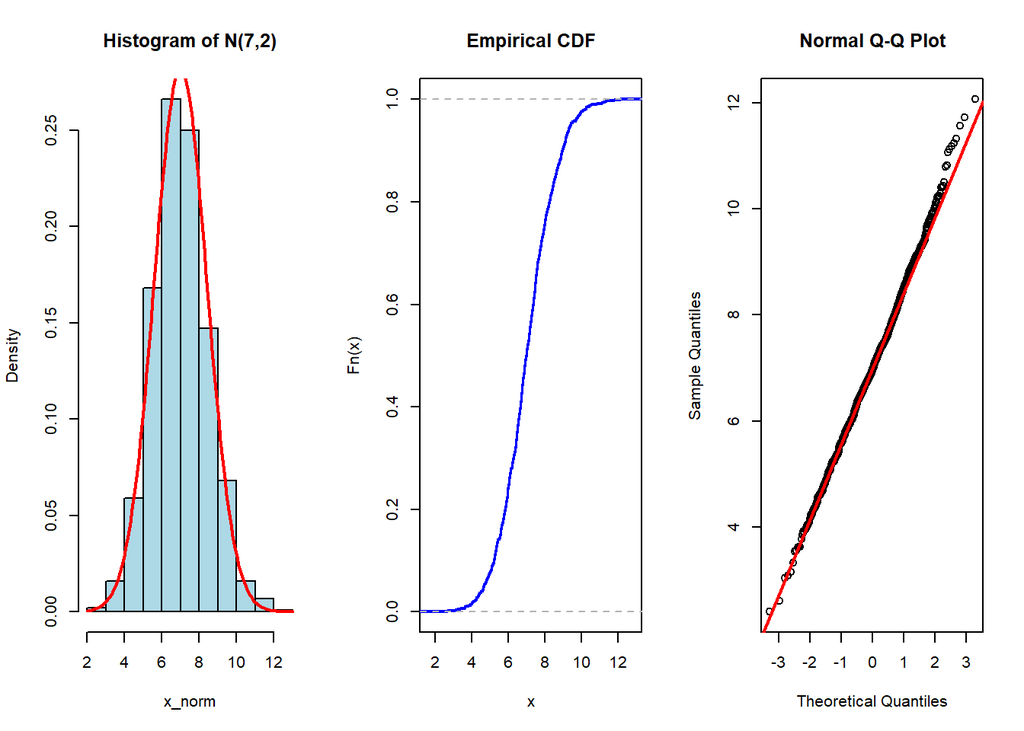

```r
set.seed(130)
n <- 1000
x_norm <- rnorm(n, mean=7, sd=sqrt(2))
# Note: R uses Standard Deviation, so we use sqrt(2)

#Visualization
par(mfrow=c(1,3))

#1. Histogram
hist(x_norm, probability=TRUE, main="Histogram of N(7,2)", col="lightblue")
curve(dnorm(x, 7, sqrt(2)), add=TRUE, col="red", lwd=2)

# 2. Empirical Cumulative Distribution Function (ECDF)
plot(ecdf(x_norm), main = "Empirical CDF", col = "blue", lwd=2)

# 3. Q-Q Plot
qqnorm(x_norm); qqline(x_norm, col = "red", lwd=2)
```

Data Generation: 1000 realizations were generated with a theoretical mean of 7.

Histogram: The data follows the classic “bell shape,” centered at 7. The red density curve fits the bars well.

ECDF: The S-shaped curve is smooth, showing the cumulative probability increasing steadily around the mean.

3.2 Student’s t Distribution (v=1 and $v=10)

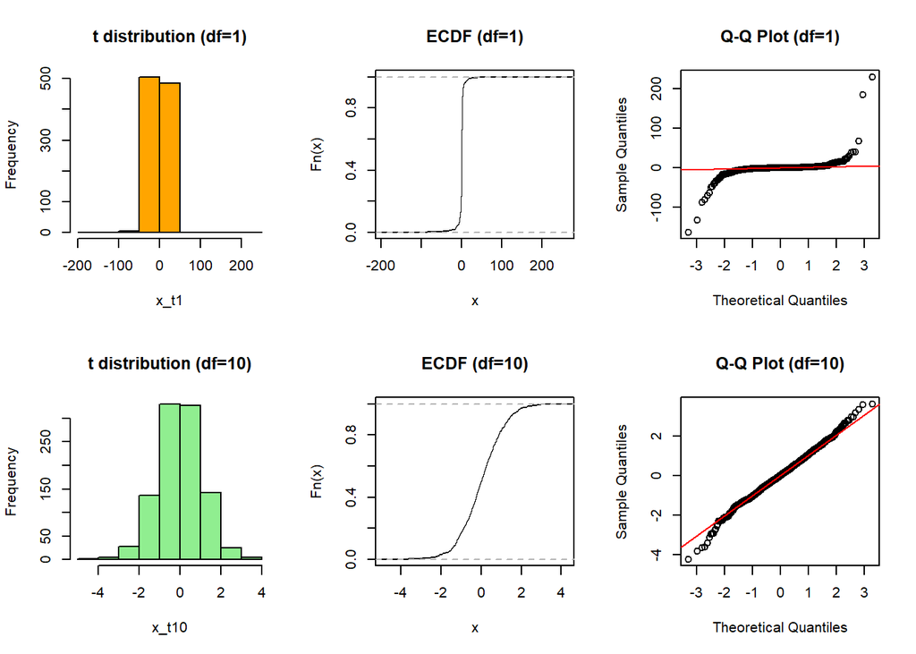

```r
set.seed(1000)
x_t1 <- rt(1000, df = 1)  # Cauchy-like, heavy tails
x_t10 <- rt(1000, df = 10) # Approaches Normal distribution

# Comparative Plots
par(mfrow=c(2,3))

# Plots for t(1)
hist(x_t1, main="t distribution (df=1)", col="orange")
plot(ecdf(x_t1), main="ECDF (df=1)")
qqnorm(x_t1, main="Q-Q Plot (df=1)"); qqline(x_t1, col="red")

# Plots for t(10)
hist(x_t10, main="t distribution (df=10)", col="lightgreen")
plot(ecdf(x_t10), main="ECDF (df=10)")
qqnorm(x_t10, main="Q-Q Plot (df=10)"); qqline(x_t10, col="red")
```

Comparison of Histograms: The $t(1)$ distribution shows extreme outliers (very wide x-axis), whereas $t(10)$ looks much more like a standard normal distribution.

ECDF Comparison: The $t(1)$ ECDF has a very sharp jump at the center because of the heavy tails, while $t(10)$ is a smoother S-curve.Q-Q Plot

Comparison:

For $v=1$, the Q-Q plot shows a “U” or “S” shape deviation at the ends, indicating heavy tails (outliers).

For $v=10$, the Q-Q plot is much closer to the straight line, showing that as degrees of freedom increase, the Student’s t distribution converges to the Normal distribution.